# Replication Code: A Replication of *Embedding Regression: Models for Context-Specific Description and Inference* (Rodriguez et al., 2023)

Replicate framework use case 1

Author

Bridgette Sullivan & Maria Bartlett

Published

April 1, 2025

### Set-up

```r
# clear global environment
rm(list = ls())

# set seed
set.seed(12345)

# provide instruction for how to install user-written packages
#devtools::install_github("prodriguezsosa/conText")

# load packages
library(tidyverse)
library(conText)
library(quanteda)
library(kableExtra)

# set processing/display options
options(mc.cores = parallel::detectCores())
options(dplyr.summarise.inform = FALSE)
options(warn = -1)

# set relative paths
root       <- file.path(getwd() %>% dirname())
author_rep <- file.path(root,"02_DataverseMaterials","dataverse_files")

# define kable styling options
kable_style <- function(df) {

  df %>%
  kbl(full_width = T,
      align = "l",
      booktabs = T) %>%
  kable_styling(latex_options = c("repeat_header","scale_down","HOLD_position"))
}
```

### Load data

```r
# corpus
cr <- readRDS(file.path(author_rep,"data","corpus_daily.rds")) %>%
  filter(session_id %in% 111:114 & party %in% c('D', 'R')) %>%
  select(speech, party, gender) %>%
  mutate(speech = tolower(iconv(speech, from = "latin1", to = "UTF-8"))) %>%
  distinct(speech, .keep_all = TRUE) %>% tidyr::drop_na() %>%
  select(speech, party, gender)

# quanteda corpus
cr_corpus <- corpus(cr$speech, docvars = data.frame(party = cr$party, gender = cr$gender))

# pre-trained GloVe embeddings
pre_trained <- readRDS(file.path(author_rep,"data","stanford-glove","glove.rds"))

# confirm GloVe is comprised of 300-dimension embeddings for 400,000 tokens
stopifnot(nrow(pre_trained) == 400000 & ncol(pre_trained) == 300)

# pre-trained transformation matrix (A_hat)
transform_matrix <- readRDS(file.path(author_rep,"data","stanford-glove","khodakA.rds"))

# confirm transformation matrix is 300 x 300
stopifnot(nrow(transform_matrix) == 300 & ncol(transform_matrix) == 300)
```

### Analysis: Differences in word meanings by gender and party

#### Preprocessing

```r
cr_toks <- tokens(cr_corpus, remove_punct = T, remove_symbols = T, remove_numbers = T, remove_url = T, remove_separators = T)
```

#### conText Regressions

```r
# define target words
targets <- c('and', 'but', 'also', 'abortion', 'marriage', 'immigration')

# initialize model vectors
models <- vector('list', length = length(targets)) %>% setNames(targets)

# run conText regressions
set.seed(2022L)
for(target in targets){

  # too many instances of these stopwords, too slow. we use a sample instead.
  if(target %in% c('and','but','also')){

    model1 <- conText(formula =  as.formula(paste0(target, ' ~ party + gender')),
                      data = tokens_sample(cr_toks, size = 0.05*length(cr_toks), replace = FALSE),
                      pre_trained = pre_trained,
                      transform = TRUE,
                      transform_matrix = transform_matrix,
                      bootstrap = TRUE,
                      jackknife = FALSE,
                      num_bootstraps = 100,
                      stratify = TRUE,
                      permute = TRUE,
                      num_permutations = 100,
                      window = 6L,
                      valuetype = 'fixed',
                      case_insensitive = TRUE,
                      hard_cut = FALSE,
                      verbose = FALSE)
  }

  else{

    model1 <- conText(formula =  as.formula(paste0(target, ' ~ party + gender')),
                      data = cr_toks,
                      pre_trained = pre_trained,
                      transform = TRUE,
                      transform_matrix = transform_matrix,
                      bootstrap = TRUE,
                      jackknife = FALSE,
                      num_bootstraps = 100,
                      stratify = TRUE,
                      permute = TRUE,
                      num_permutations = 100,
                      window = 6L,
                      valuetype = 'fixed',
                      case_insensitive = TRUE,
                      hard_cut = FALSE,
                      verbose = FALSE)
  }

  model1@normed_coefficients %>% kable_style()

  models[[target]] <- model1
  cat("done with", target, "\n")

}
```

Note: These values are not regression coefficients. Check out the Quick Start Guide for help with interpretation: https://github.com/prodriguezsosa/conText/blob/master/vignettes/quickstart.md

coefficient normed.estimate std.error lower.ci upper.ci p.value 1 party_R 0.03615848 0.0008181605 0.03473171 0.03760620 0 2 gender_M 0.03527124 0.0011202052 0.03299869 0.03722872 0 done with and Note: These values are not regression coefficients. Check out the Quick Start Guide for help with interpretation: https://github.com/prodriguezsosa/conText/blob/master/vignettes/quickstart.md

coefficient normed.estimate std.error lower.ci upper.ci p.value 1 party_R 0.03294932 0.00165944 0.03006530 0.03682141 0 2 gender_M 0.04586265 0.00279926 0.04030571 0.05130622 0 done with but Note: These values are not regression coefficients. Check out the Quick Start Guide for help with interpretation: https://github.com/prodriguezsosa/conText/blob/master/vignettes/quickstart.md

coefficient normed.estimate std.error lower.ci upper.ci p.value 1 party_R 0.04898049 0.002964708 0.04351522 0.05382743 0 2 gender_M 0.04920916 0.003158202 0.04337075 0.05525015 0 done with also Note: These values are not regression coefficients. Check out the Quick Start Guide for help with interpretation: https://github.com/prodriguezsosa/conText/blob/master/vignettes/quickstart.md

coefficient normed.estimate std.error lower.ci upper.ci p.value 1 party_R 0.10495214 0.003673300 0.09850555 0.11186067 0 2 gender_M 0.05424467 0.003781241 0.04815196 0.06090739 0 done with abortion Note: These values are not regression coefficients. Check out the Quick Start Guide for help with interpretation: https://github.com/prodriguezsosa/conText/blob/master/vignettes/quickstart.md

coefficient normed.estimate std.error lower.ci upper.ci p.value 1 party_R 0.1253472 0.005678696 0.11493548 0.1360641 0 2 gender_M 0.1061285 0.007882997 0.09428578 0.1265728 0 done with marriage Note: These values are not regression coefficients. Check out the Quick Start Guide for help with interpretation: https://github.com/prodriguezsosa/conText/blob/master/vignettes/quickstart.md

coefficient normed.estimate std.error lower.ci upper.ci p.value 1 party_R 0.17513562 0.002807971 0.17087354 0.18145452 0 2 gender_M 0.08709909 0.003890226 0.08028668 0.09517682 0 done with immigration

```r
normed_cofficients <- lapply(targets, function(target) cbind(target = target, models[[target]]@normed_coefficients)) %>% bind_rows()
normed_cofficients <- normed_cofficients %>% mutate(target = factor(target, levels = c('also', 'but', 'and', 'abortion', 'marriage', 'immigration')),
                                        coefficient = factor(coefficient, levels = c('party_R', 'gender_M')))
```

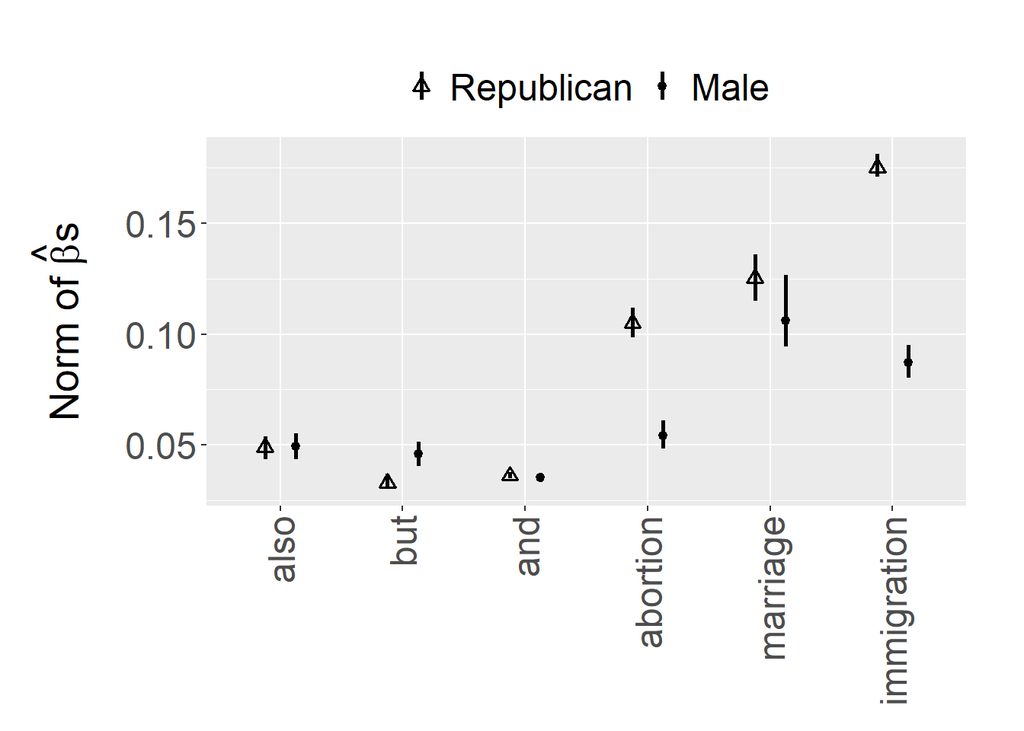

```r
ggplot(normed_cofficients, aes(coefficient, shape = coefficient)) +
  geom_pointrange(aes(x = target, y = normed.estimate,
                      ymin = lower.ci,
                      ymax = upper.ci), lwd = 1, position = position_dodge(width = 1/2), fill = "WHITE") +
  xlab('') +
  ylab(expression(paste('Norm of ', hat(beta),'s'))) +
  scale_shape_manual(values=c(2,20), labels = c("Republican", "Male")) +
  theme(axis.text.x = element_text(size=18, angle = 90, vjust = 0.5, hjust = 1),
        axis.text.y = element_text(size=18),
        axis.title.y = element_text(size=20, margin = margin(t = 0, r = 15, b = 0, l = 15)),
        legend.text=element_text(size=18),
        legend.title=element_blank(),
        legend.key=element_blank(),
        legend.position = "top",
        legend.spacing.x = unit(0.25, 'cm'),
        plot.margin=unit(c(1,1,0,0),"cm"))
```

#### Nearest neighbors

```r
#---------------------------------
# nearest neighbors using model
#---------------------------------

# just for immigration as a function of party
model1 <- conText(formula =  immigration ~ party,
                  data = cr_toks,
                  pre_trained = pre_trained,
                  transform = TRUE,
                  transform_matrix = transform_matrix,
                  bootstrap = TRUE,
                  jackknife = FALSE,
                  num_bootstraps = 100,
                  confidence_level = 0.95,
                  stratify = TRUE,
                  permute = TRUE,
                  num_permutations = 100,
                  window = 6L,
                  valuetype = 'fixed',
                  case_insensitive = TRUE,
                  hard_cut = FALSE,
                  verbose = FALSE)
```

Note: These values are not regression coefficients. Check out the Quick Start Guide for help with interpretation: https://github.com/prodriguezsosa/conText/blob/master/vignettes/quickstart.md

coefficient normed.estimate std.error lower.ci upper.ci p.value 1 party_R 0.1623825 0.002770451 0.1572752 0.1674456 0

```r
# extract coefficients
immigrationR <- model1["(Intercept)",] + model1["party_R",]
immigrationD <- model1["(Intercept)",]

# nearest neighbors
nns_R <- nns(immigrationR, pre_trained = pre_trained, N = 10, candidates = model1@features, as_list = FALSE)
nns_D <- nns(immigrationD, pre_trained = pre_trained, N = 10, candidates = model1@features, as_list = FALSE)

nns_R %>% kable_style()
```

| target | feature | rank | value |
| --- | --- | --- | --- |
| NA | enforce | 1 | 0.5003589 |
| NA | laws | 2 | 0.4963546 |
| NA | enact | 3 | 0.4916639 |
| NA | enacting | 4 | 0.4878120 |
| NA | legislate | 5 | 0.4877142 |
| NA | legislations | 6 | 0.4768726 |
| NA | enforcing | 7 | 0.4761531 |
| NA | regularize | 8 | 0.4673827 |
| NA | immigration | 9 | 0.4632692 |
| NA | legislation | 10 | 0.4596567 |

```r
nns_D %>% kable_style()
```

| target | feature | rank | value |
| --- | --- | --- | --- |
| NA | enact | 1 | 0.5486623 |
| NA | overhauling | 2 | 0.5332835 |
| NA | reform | 3 | 0.5318876 |
| NA | legislation | 4 | 0.5222219 |
| NA | enacting | 5 | 0.5164900 |
| NA | overhaul | 6 | 0.5107466 |
| NA | revamp | 7 | 0.4955377 |
| NA | reforming | 8 | 0.4954041 |
| NA | entitlement | 9 | 0.4629089 |
| NA | bipartisan | 10 | 0.4563845 |

#### Nearest contexts

```r
# tokenize docs
immig_toks <- tokens_context(cr_toks, pattern = 'immigration', window = 6L, hard_cut = FALSE)
```

15858 instances of “immigration” found.

```r
# build dfm
immig_dfm <- dfm(immig_toks)

# build dem
immig_dem <- dem(x = immig_dfm, pre_trained = pre_trained, transform = TRUE, transform_matrix = transform_matrix, verbose = TRUE)

# compute ALC embeddings for each party
immig_wv_party <- dem_group(immig_dem, groups = immig_dem@docvars$party)

# find nearest contexts (limit each party's ncs to their own contexts)
ncs_R <- ncs(x = immig_wv_party["R",],
             contexts_dem = immig_dem[immig_dem@docvars$party == "R",],
             contexts = immig_toks[docvars(immig_toks, 'party') == "R",],
             N = 5,
             as_list = FALSE)

ncs_D <- ncs(x = immig_wv_party["D",],
             contexts_dem = immig_dem[immig_dem@docvars$party == "D",],
             contexts = immig_toks[docvars(immig_toks, 'party') == "D",],
             N = 5,
             as_list = FALSE)

ncs_R %>% kable_style()
```

| target | context | rank | value |
| --- | --- | --- | --- |
| NA | we would still have to do reform because the immigration system is | 1 | 0.6778998 |
| NA | administration wants to ignore our nations laws and immigration process the problem | 2 | 0.6727489 |
| NA | the immigration laws because you see services has decided well we are | 3 | 0.6726239 |
| NA | we need true reform of our laws starting with border security and | 4 | 0.6680008 |
| NA | broken is the enforcement of our laws and we have seen that | 5 | 0.6677501 |

```r
ncs_D %>% kable_style()
```

| target | context | rank | value |
| --- | --- | --- | --- |
| NA | this congress to take on comprehensive reform and fix our broken immigration | 1 | 0.8041028 |
| NA | should get to work on comprehensive reform the immigration system we have | 2 | 0.7906793 |
| NA | comprehensive immigration reform americans want comprehensive reform we have a bill h.r | 3 | 0.7902469 |
| NA | to passing comprehensive immigration reform our laws are broken our system is | 4 | 0.7902154 |
| NA | broken immigration system we need comprehensive reform and an act of congress | 5 | 0.7836782 |